# Gráficos con ggplot2 (A): Primeras ideas

## Un gráfico es un objeto de R: podemos guardarlo y añadirle capas

- Un gráfico de ggplot2 es un objeto más de R: podemos **guardarlo con un nombre** (`<-`) y luego **añadirle capas con `+`**

```r
p <- ggplot(iris, aes(Sepal.Length, Petal.Length, color = Species)) +
  geom_point()
```

- `p` no se dibuja al crearlo; se dibuja cuando lo “imprimimos” (al escribir `p` o `print(p)`)

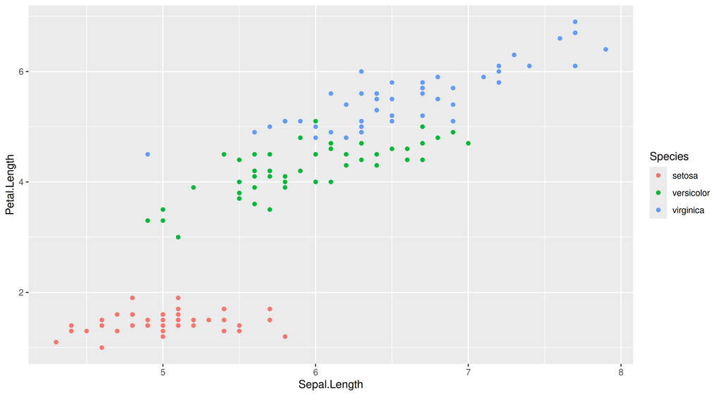

```r
p
```

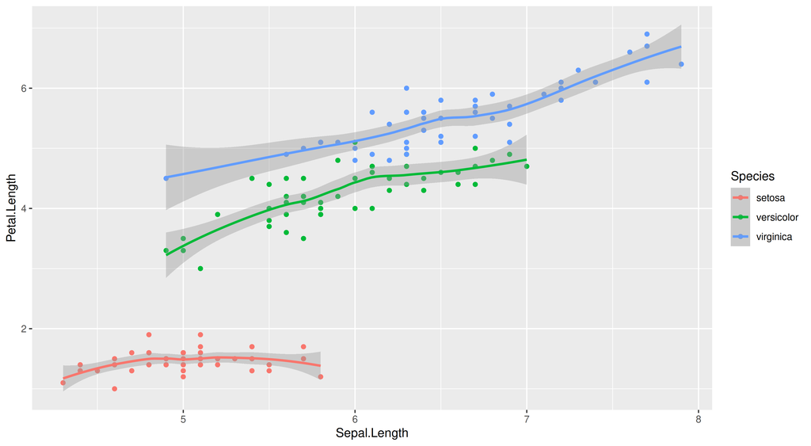

```r
p + geom_smooth()
```

- Lo usaremos mucho en las siguientes slides: haremos un gráfico `p` y le iremos añadiendo cosas (títulos, temas, …)

## ¿Veremos alguna vez otros gráficos?

- ¡SÍ! Pero aún falta un poco, hemos de ver más cosas (y sí, usando `iris`)
- Si no puedes esperarte, mira la [R Graph Gallery](https://r-graph-gallery.com/) (cientos de gráficos con su código) o la [galería de extensiones de ggplot2](https://exts.ggplot2.tidyverse.org/gallery/)

*the aesthetic parameters* de cada geom_xx()

- Cuando empecemos a hacer otros tipos de gráficos será de utilidad conocer qué parámetros admite cada `geom_xx()`
- Puedes verlos en la ayuda de cada `geom` (por ejemplo `?geom_point`, sección *Aesthetics*), en la [web de ggplot2](https://ggplot2.tidyverse.org/reference/) o en la viñeta `vignette("ggplot2-specs")`

## Para practicar: los pingüinos de Palmer

Desde R 4.5, el paquete `datasets` incluye `penguins`: datos de 344 pingüinos de 3 especies del archipiélago Palmer (Antártida)

- Tarea
- Solución

Tarea: haz un gráfico de puntos con la longitud de la aleta (`flipper_len`) en el eje X, el peso (`body_mass`) en el eje Y y el color según la especie (`species`). Añade una recta de regresión para cada especie con `geom_smooth(method = "lm")`

```r
head(penguins, n = 3)
```

```
#>   species    island bill_len bill_dep flipper_len body_mass    sex year
#> 1  Adelie Torgersen     39.1     18.7         181      3750   male 2007
#> 2  Adelie Torgersen     39.5     17.4         186      3800 female 2007
#> 3  Adelie Torgersen     40.3     18.0         195      3250 female 2007
```

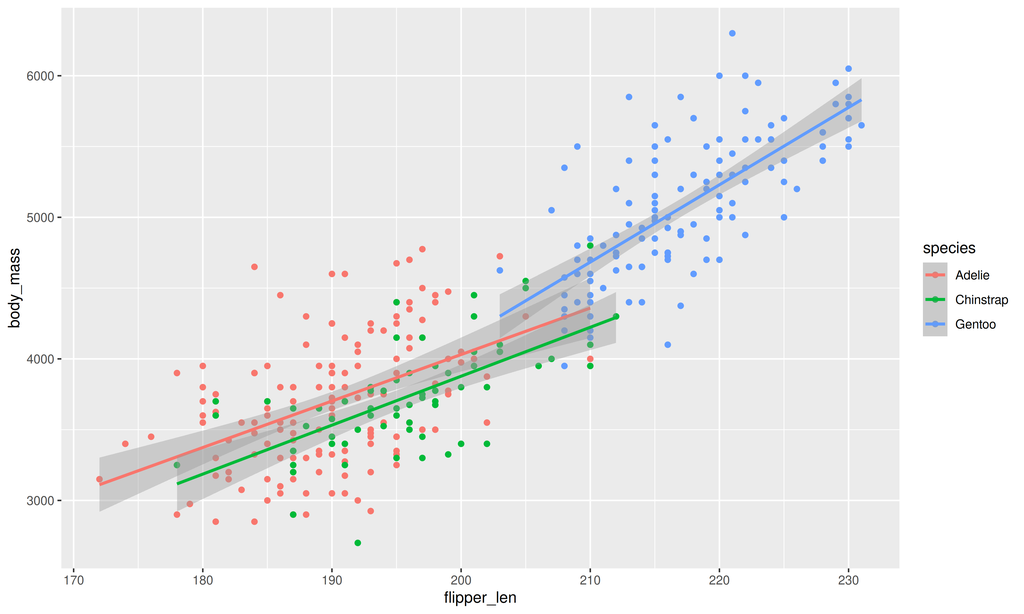

```r
ggplot(penguins, aes(flipper_len, body_mass, color = species)) +
  geom_point() +
  geom_smooth(method = "lm")
```

## Para saber más

- El libro de Hadley Wickham, Danielle Navarro y Thomas Lin Pedersen: [*ggplot2: Elegant Graphics for Data Analysis* (3ª ed.)](https://ggplot2-book.org/), gratis online
- El capítulo de visualización de [*R for Data Science* (2ª ed.)](https://r4ds.hadley.nz/data-visualize)
- La [cheatsheet de ggplot2](https://rstudio.github.io/cheatsheets/data-visualization.pdf)
- La [documentación de ggplot2](https://ggplot2.tidyverse.org/reference/): todas las funciones, con ejemplos

En las siguientes slides veremos más elementos de un ggplot: títulos, themes, facetting, anotaciones, escalas, …